# R for Data Science, Chapter 3

### 3.3.1 Exercises

**1. What’s wrong with this code? Why are the points not blue?**

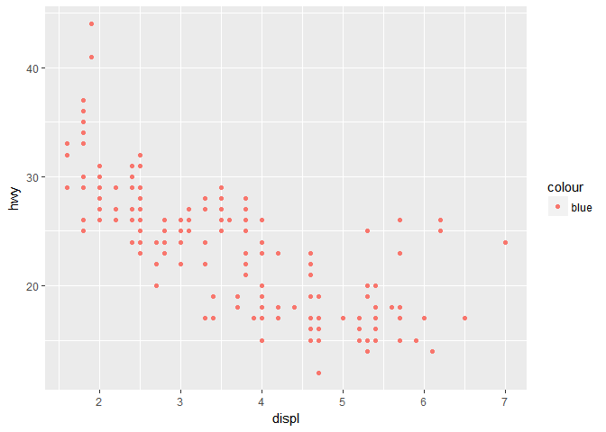

```r
ggplot(data = mpg) +
  geom_point(mapping = aes(x = displ, y = hwy, color = "blue"))
```

*The color option doesn’t actually take a color argument. It takes another set of date, like class, and colors the points on the graph according to the different classes the points fall into. Since there are 7 classes, there would be 7 different colors on the graph. To properly get the blue color, one sets color = “blue” outside of aes().*

**2. Which variables in mpg are categorical? Which variables are continuous? Hint: type `?mpg` to read the documentation for the dataset. How can you see this information when you run mpg?**  
*`Manufacturer`, `model`, `trans`, `fl`, and `class` are all categorical. When you run `mpg`, the columns (variables) are classified as `<int>` or `<dbl>` for numbers and `<chr>` for character, or letters/words.*

**3. Map a continous variable to color, size, and shape. How do these aesthetics behave differently for categorical vs continous variables?**  
*First, r throws an error that a continous variable cannot be mapped to shape. So let’s try it without giving a shape.*

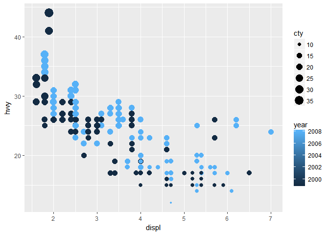

```r
ggplot(data = mpg) +
  geom_point(mapping = aes(x = displ, y = hwy, color = year, size = cty))
```

*If a continous variable is given for color, it appears that the color is then based on a gradient instead of each year being it’s own distinct color. As for size, a continous variable seems to have the same effect. Luckily, cty had consistent increments so the size distribution looks constant.*

**4. WHat happens if you map the same variable to multiple aesthetics?**

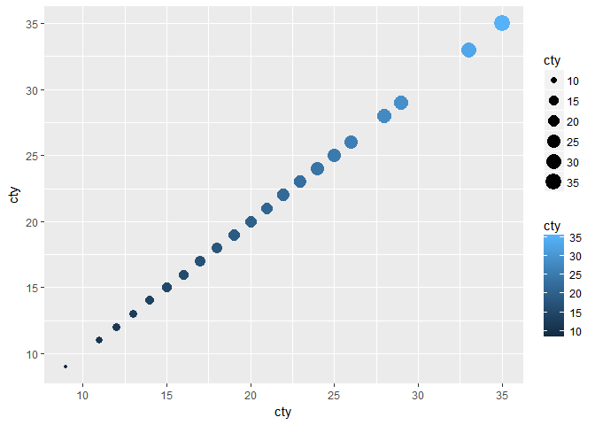

```r
ggplot(data = mpg) +
  geom_point(mapping = aes(x = cty, y = cty, color = cty, size = cty))
```

*As an extreme test, I made each option in aesthetics the same variable `cty`. The resulting plot is a straight line with a continous range of colors and sizes for the data points.*

**5. What does the `stroke` aesthetic do? What shapes does it work with? Hint: use `?geom_point`.**  
*The `stroke` aesthetic modifies the width of the border of outlined data points.*

**6. What happens if you map an aesthetic to something other than a variable name, like `aes(color = displ < 5)`?**

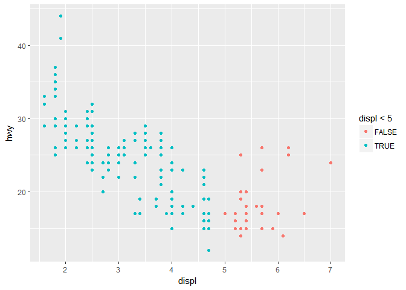

```r
ggplot(data = mpg) +
  geom_point(mapping = aes(x = displ, y = hwy, color = displ < 5))
```

*It appears that this sets a rule for the color. If the `displ` is less than 5, the data point is colored one way and another way if it is not less than 5. However, this particular example only appears to be binary.*

### 3.5.1 Exercises

*Note: A facet is part of the main plot. It split up the plot into subplots that display one subset of the data. To facet by 1 variable, use `facet_wrap()`. To use two variables, use `facet_grid()`. It is similar to `wrap`, except the two variable names are separated by `~` instead of that `~` preceeding a single variable name.*

**1. What happens if you facet on a continuous variable?**  
*The text indicates that the variable passed to `facet_wrap()` should be discrete. So my guess is that giving it a continuous variable will throw an error.*

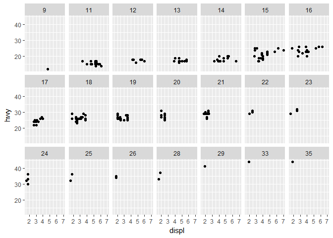

```r
ggplot(data = mpg) +
  geom_point(mapping = aes(x = displ, y = hwy)) +
  facet_wrap(~ cty, nrow = 3)
```

*Well, upon running the code, it clearly does not throw an error. Instead we just get many many plots.*

**2. What do the empty cells in plot with `facet_grid(drv ~ cyl)` mean? How do they relate to this plot?**

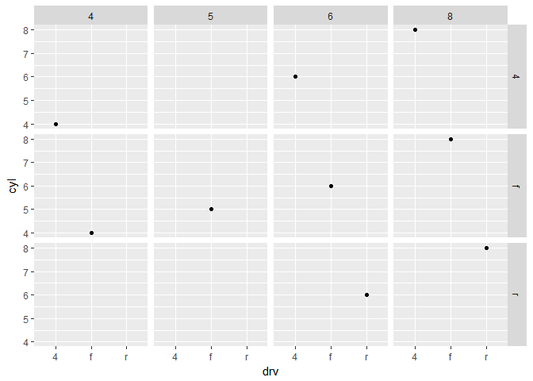

```r
ggplot(data = mpg) +
  geom_point(mapping = aes(x = drv, y = cyl)) +
  facet_grid(drv ~ cyl)
```

*The empty cells indicate that there is no data there. For example, there are no cars that have 4 cylinders that are also rear-wheel drive.*

**3. What plots does the following code make? What does . do?**

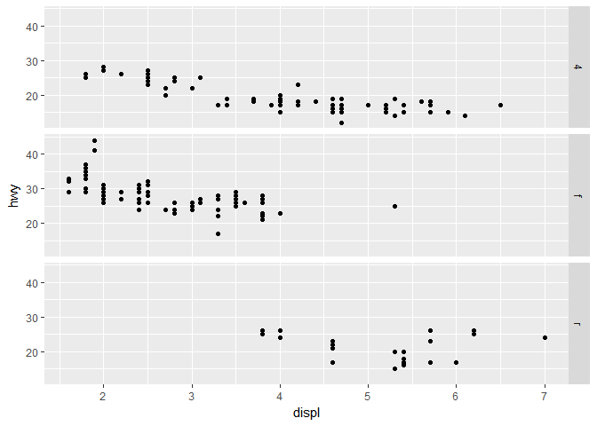

```r
ggplot(data = mpg) +
  geom_point(mapping = aes(x = displ, y = hwy)) +
  facet_grid(drv ~ .)
```

*The texts says to use `.` instead of a variable name to not facet in the rows or columns dimension. Because the `.` was the second variable, we faceted into a column instead of a row.*

**4. Take the first faceted plot in this section:**

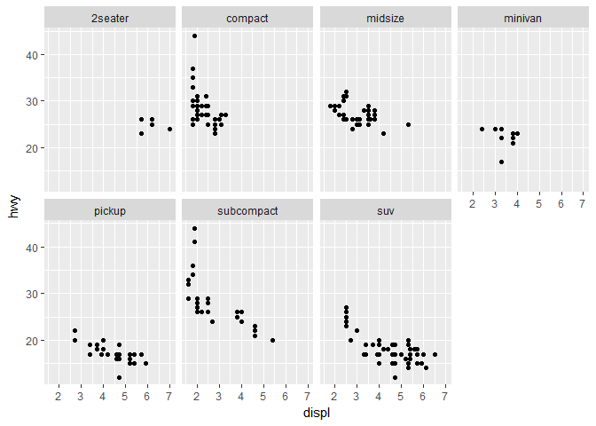

```r
ggplot(data = mpg) +
  geom_point(mapping = aes(x = displ, y = hwy)) +
  facet_wrap(~ class, nrow = 2)
```

**What are the advantages to using faceting instead of the colour aesthetic? What are the disadvantages? How might the balance change if you had a larger dataset?**  
*Faceting clearly arranges the data by multiple variables, allowing for a nice visualization of a lot of data. However, with more data, the color aesthetic is better suited; faceting would just make a mess of it all.*

**5. Read `?facet_wrap`. What does `nrow` do? What does `ncol` do? WHat other options control the layout of the individual panels? Why doesn’t `facet_grid()` have `nrow` and `ncol` variables?**  
*`nrow` and `ncol` designate the number of rows and columns. The `facet_grip()` command doesn’t have this because the number of rows and columns depends on the number of categories in each variable given. The other options that control the layout are `dir`, `strip.position`, `switch`, `as.table`, `scales`, and `shrink`.*

**6. When using `facet_grid()` you should usually put the variable with more unique levels in the columns. Why?**  
*It makes the layout visually more appealing. Here is an example of the convention flipped, where the variable with more unique levels is in the rows.*

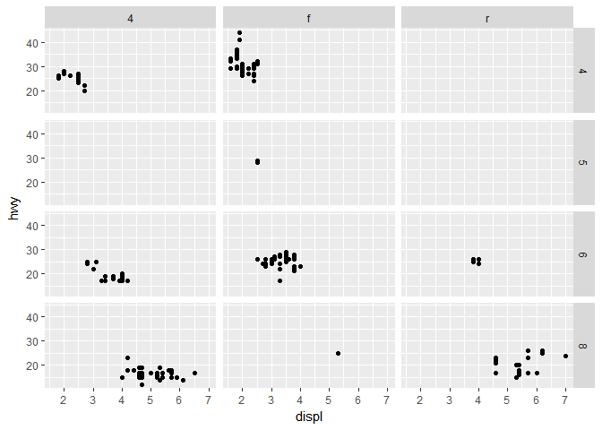

```r
ggplot(data = mpg) +
  geom_point(mapping = aes(x = displ, y = hwy)) +
  facet_grid(cyl ~ drv)
```

*And here is having the more unique variable in the columns.*

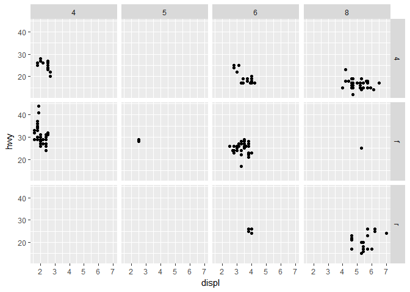

```r
ggplot(data = mpg) +
  geom_point(mapping = aes(x = displ, y = hwy)) +
  facet_grid(drv ~ cyl)
```